# Alone

Braden Buchanan

2023-09-06

# Load Alone Tidy Tuesday Data

```r
survivalists <- readr::read_csv('https://raw.githubusercontent.com/rfordatascience/tidytuesday/master/data/2023/2023-01-24/survivalists.csv')
loadouts <- readr::read_csv('https://raw.githubusercontent.com/rfordatascience/tidytuesday/master/data/2023/2023-01-24/loadouts.csv')
episodes <- readr::read_csv('https://raw.githubusercontent.com/rfordatascience/tidytuesday/master/data/2023/2023-01-24/episodes.csv')
seasons <- readr::read_csv('https://raw.githubusercontent.com/rfordatascience/tidytuesday/master/data/2023/2023-01-24/seasons.csv')
```

Load packages

```r
library(tidyverse)
```

# Descriptive Statistics

### Where are the different participants from in the country?

```r
survivalists %>%
  group_by(country) %>%
  count()
```

```
## # A tibble: 4 × 2
## # Groups:   country [4]
##   country                 n
##   <chr>               <int>
## 1 Canada                 13
## 2 U.S. Virgin Islands     1
## 3 United Kingdom          1
## 4 United States          79
```

Majority of participants are from the United States. In total across 9 seasons, 79/94 from the United States, followed by 13/94 from Canada.

### What states are most US participants from?

```r
survivalists %>%
  group_by(state) %>%
  count() %>%
  arrange(desc(n))
```

```
## # A tibble: 41 × 2
## # Groups:   state [41]
##    state                n
##    <chr>            <int>
##  1 Alaska              11
##  2 Maine                6
##  3 Ontario              5
##  4 Utah                 5
##  5 Washington           5
##  6 Colorado             4
##  7 Pennsylvania         4
##  8 British Columbia     3
##  9 Idaho                3
## 10 Illinois             3
## # ℹ 31 more rows
```

### What country are most winners from?

```r
survivalists %>%
  select(season, country, result, days_lasted, profession) %>%
  filter(result == 1) %>%
  group_by(country)
```

```
## # A tibble: 10 × 5
## # Groups:   country [2]
##    season country       result days_lasted profession
##     <dbl> <chr>          <dbl>       <dbl> <chr>
##  1      1 United States      1          56 Corrections Officer
##  2      2 United States      1          66 Writer and Former Missionary
##  3      3 United States      1          87 Boat builder
##  4      4 Canada             1          75 Freelance Writer
##  5      4 Canada             1          75 Adventure Videographer
##  6      5 United States      1          60 Wilderness Skills Instructor
##  7      6 United States      1          77 Construction
##  8      7 United States      1         100 Hunting Guide
##  9      8 United States      1          74 Professional Bowyer & Hunter
## 10      9 Canada             1          78 Outdoor Professional
```

### Male vs female winners

```r
survivalists %>%
  filter(result == "1") %>%
  group_by(season, gender, days_lasted) %>%
  summarise(winner_count = n())
```

```
## # A tibble: 9 × 4
## # Groups:   season, gender [9]
##   season gender days_lasted winner_count
##    <dbl> <chr>        <dbl>        <int>
## 1      1 Male            56            1
## 2      2 Male            66            1
## 3      3 Male            87            1
## 4      4 Male            75            2
## 5      5 Male            60            1
## 6      6 Male            77            1
## 7      7 Male           100            1
## 8      8 Male            74            1
## 9      9 Male            78            1
```

Over 9 seasons of Alone, only males have came in first place.

### How many women came in 2nd place and avg days lasted?

```r
survivalists %>%
  filter(result == 2 & gender == "Female") %>%
  group_by(season, gender, days_lasted) %>%
  summarize(second_place = n())
```

```
## # A tibble: 4 × 4
## # Groups:   season, gender [4]
##   season gender days_lasted second_place
##    <dbl> <chr>        <dbl>        <int>
## 1      3 Female          86            1
## 2      6 Female          73            1
## 3      7 Female          89            1
## 4      9 Female          75            1
```

```r
survivalists %>%
  select(gender, days_lasted, result) %>%
  filter(result == 2 & gender == "Female") %>%
  mutate(avg_days_lasted = mean(days_lasted))
```

```
## # A tibble: 4 × 4
##   gender days_lasted result avg_days_lasted
##   <chr>        <dbl>  <dbl>           <dbl>
## 1 Female          86      2            80.8
## 2 Female          73      2            80.8
## 3 Female          89      2            80.8
## 4 Female          75      2            80.8
```

4x Women came in second place. On average, the 2nd place women last 80.8 days

### What were the main reasons for participants to tap out?

```r
survivalists %>%
  select(season, reason_tapped_out, result, gender) %>%
  filter(!is.na(reason_tapped_out)) %>%
  mutate(reason_tapped_out = ifelse(str_detect(reason_tapped_out, "Starvation"), "Starvation", reason_tapped_out)) %>%
  count(reason_tapped_out) %>%
  arrange(desc(n))
```

```
## # A tibble: 59 × 2
##    reason_tapped_out                                        n
##    <chr>                                                <int>
##  1 Starvation                                               9
##  2 Missed his family                                        6
##  3 Low BMI, lost too much weight                            3
##  4 Fear of bears                                            2
##  5 Felt too exhausted and drained to go on                  2
##  6 Food poisoning                                           2
##  7 Injured ankle                                            2
##  8 Jointly decided the cost of the game wasn't worth it     2
##  9 Lonely                                                   2
## 10 Lower back injury                                        2
## # ℹ 49 more rows
```

Most participants tap out due to starvation or missing their family.

### Main reason for 2nd place for tapping out?

```r
library(stringr)

survivalists %>%
  select(season, reason_tapped_out, result, gender) %>%
  filter(!is.na(reason_tapped_out), result == 2) %>%
  mutate(reason_tapped_out = ifelse(str_detect(reason_tapped_out, "Starvation"), "Starvation", reason_tapped_out)) %>%
  count(reason_tapped_out) %>%
  arrange(desc(n))
```

```
## # A tibble: 7 × 2
##   reason_tapped_out                                        n
##   <chr>                                                <int>
## 1 Starvation                                               3
## 2 Jointly decided the cost of the game wasn't worth it     2
## 3 BMI too low                                              1
## 4 Frostbite of the toes                                    1
## 5 Hunger and mental breakdown                              1
## 6 Lost the mind game                                       1
## 7 Missed his family                                        1
```

Main reasons participants in 2nd place tapped out was due to starvation.

### Most common equipment participants had

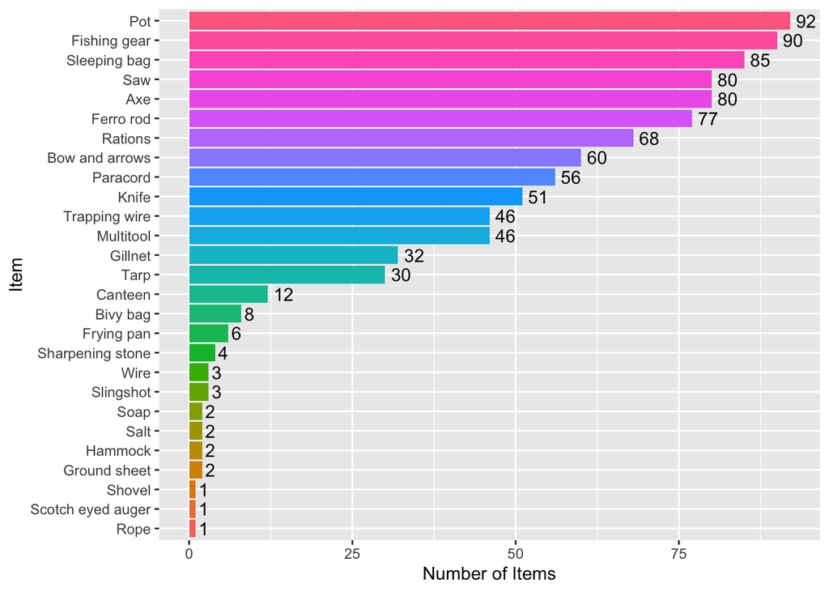

```r
mostCommonLoadouts <- loadouts %>%
  select(item_number, item_detailed, item) %>%
  count(item) %>%
  mutate(item = fct_reorder(item, n)) %>%
  arrange(desc(n))

ggplot(mostCommonLoadouts, aes(x = item, y = n, fill = item)) +
  geom_bar(stat="identity") +
    geom_text(aes(label=n), position=position_dodge(width=0.9), hjust=-0.3) +
  coord_flip() +
  labs(x = "Item",
       y = "Number of Items") +
  theme(legend.position = "none")
```

Pots, fishing gear, and sleeping bags were the most common loadouts for participants.

# Inferential Statistics

Use a t-test to see if gender significantly affects the number of days lasted.

```r
# Filtering data to exclude rows where 'days_lasted' is NA
filtered_data <- survivalists %>%
  filter(!is.na(days_lasted))

t_test_result <- t.test(days_lasted ~ gender, data = filtered_data)

print(t_test_result)
```

```
##
##  Welch Two Sample t-test
##
## data:  days_lasted by gender
## t = 1.8609, df = 29.081, p-value = 0.0729
## alternative hypothesis: true difference in means between group Female and group Male is not equal to 0
## 95 percent confidence interval:
##  -1.308013 27.748554
## sample estimates:
## mean in group Female   mean in group Male
##             49.45000             36.22973
```

Men and women seem to last different amounts of time on the show, with women lasting longer on average. However, we’re not 100% sure if this difference is because of gender or just happened by chance. We’d need more evidence or a stronger result to be certain.

### Is age correlated with success in the show?

```r
# Compute the correlation
correlation <- cor(survivalists$age, survivalists$days_lasted, use = "complete.obs")

print(correlation)
```

```
## [1] 0.06623176
```

```r
# Compute the correlation for age and result
correlation_result <- cor(survivalists$age, survivalists$result, use = "complete.obs")

print(correlation_result)
```

```
## [1] -0.04187163
```

```r
# Correlation test for age and days_lasted
test_result <- cor.test(survivalists$age, survivalists$days_lasted, use = "complete.obs")

print(test_result)
```

```
##
##  Pearson's product-moment correlation
##
## data:  survivalists$age and survivalists$days_lasted
## t = 0.63667, df = 92, p-value = 0.5259
## alternative hypothesis: true correlation is not equal to 0
## 95 percent confidence interval:
##  -0.1382403  0.2652886
## sample estimates:
##        cor
## 0.06623176
```

Based on the data and tests conducted, age doesn’t seem to have a significant impact on how long participants last in the show or on their result rankings.

There is a weak positive correlation of 0.0662 between age and the number of days participants lasted in the show. However, this correlation is not statistically significant with a p-value of 0.5259.

There’s also a weak negative correlation of -0.0419 between age and the result, but the significance of this relationship wasn’t tested in the provided outputs.

### Are survivalists from certain professions more likely to succeed?

```r
contingency_table <- table(survivalists$profession, survivalists$result)
chi_squared_test <- chisq.test(contingency_table)
print(chi_squared_test)
```

```
##
##  Pearson's Chi-squared test
##
## data:  contingency_table
## X-squared = 718.12, df = 711, p-value = 0.4184
```

The data doesn’t provide strong evidence to suggest that the profession of survivalists is associated with their success on the show.

The p-value is 0.4184, which is greater than 0.05. This suggests that, based on the data we don’t have enough evidence to reject the null hypothesis.